# Exploring the Impact of biopsychosocial Factors on Hearing Loss Incidence Rates: A Population-Based Study.

Keshav Kumar

12 July, 2024

```r
###### PROLOG ########


# PROLOG   ###
# PROJECT: Capstone EHDI Paper
# PURPOSE: Capstone
# DIR:     OneDrive/Keshav-Personal/Desktop/R_git/Capstone
# DATA:    ehdi_acs_Insur_data_2015to2020_cleaned20240207.csv
# AUTHOR:  Keshav Kumar
# CREATED: Apr 22, 2024
# LATEST:  JUL 4, 2024
# NOTES:   Source for GOVT spending data:
#          ACS social explorer 2024.
#         Kaiser Family FOundation for healthcare spending data

# PROLOG   ###


# install packages and open libraries

# stargazer for model comparison
# sandwich For robust SE estimator
# broom for getting results with Robust SEs
# MASS For negative binomial
# lmtest For model comparison
# SMPracticals for lung cancer data
# ggplot2 for plots
# writing results to excel
# magrittr for pipes
# sessioninfo for session_info at bottom
# details for session_info at bottom
# ggthemes for tufte theme
# ggrepel for text plotting
# patchwork for combining plots
# sjplot for model tables
pacman::p_load(stargazer, sandwich, MASS, lmtest, SMPracticals, ggplot2, writexl, broom, broom.mixed, dplyr, tidyverse, lme4, summarytools, tableone, reshape2, kableExtra, magrittr, sessioninfo, details, ggthemes, ggrepel, patchwork, sjPlot, tinytex_root)

# plot theme
theme_set(theme_tufte())  # but might not carry over in chunks

# Okabe-Ito colorblind-friendly color palette:
# https://jfly.uni-koeln.de/color/

oi_pal <- c("#000000", "#E69F00", "#56B4E9", "#009E73", "#F0E442",
     "#0072B2", "#D55E00", "#CC79A7", "#999999")
```

```r
# # Clear existing variables from the environment
# rm(list = ls ())
# # Set the working directory to the project folder
# setwd("C:/Users/kesha/OneDrive/Desktop/R_git/Capstone")
```

### Set environment is commented out since this is in already setup in git

```r
# # Set the base folder path
# box_folder=  "C:/Users/kesha/OneDrive/Desktop/R_git/Capstone"
#
# ## Input directory
# inputData.dir <- paste(box_folder,"ACS_social_explorer_data")

## Output directory
# out.dir <- paste(box_folder,"/Output/Result", Sys.Date(), sep="")
# if (!dir.exists(out.dir)) {
#   dir.create(out.dir, recursive = TRUE)
# }
# setwd(out.dir)
```

### Data Management

```r
###### DATA MGMT #####

# Create a dataset for poission

ehdi<- read.csv("ACS_social_explorer_data/ehdi_acs_Insur_data_2015to2020_cleaned20240207.csv",header = TRUE)

ehdi_pos <- ehdi %>%
  select(`State`,`Year`,`HL`,`Total_population`, `Black_under_5yr`,`White_under_5yr`, `Pop_with_insur`,`Median_household_income`,`Health_Spending_per_Capita`) %>%
  na.omit() %>%
 mutate(Year = as.factor(Year)) #%>%
  # #mutate(PerHL = (HL/Tscr)*100) %>%
  # group_by(Year) %>%
  #             summarise(across(where(is.numeric), ~sum(., na.rm=TRUE))) %>%
  #             mutate(State="Total", Year, sep="_")


#filter states that have data for all the years for all the variables


# Check which states have data for all years
states_all_years <- ehdi_pos %>%
  group_by(State) %>%
  summarise(num_years = n_distinct(Year)) %>%
  filter(num_years == 6) %>%
  pull(State)

# Filter the dataset to include only those states
ehdi_pos <- ehdi_pos %>%
  filter(State %in% states_all_years)

#write out filtered data
#write_csv(ehdi_pos,
#          "Output/final_data/final_data_filtered.csv")
```

### Descriptive Statistics mean ± SD (min-max)

```r
descriptive_table<- ehdi_pos %>%
  group_by(Year) %>%
  summarise(
    `Hearing Loss Cases` = paste(round(mean(HL, na.rm = TRUE), 2), "±", round(sd(HL, na.rm = TRUE), 2), "(", min(HL, na.rm = TRUE), "-", max(HL, na.rm = TRUE), ")", sep = " "),
    `Black population under 5yr of age` = paste(round(mean(Black_under_5yr, na.rm = TRUE) / 1000, 2), "±", round(sd(Black_under_5yr, na.rm = TRUE) / 1000, 2), "(", round(min(Black_under_5yr, na.rm = TRUE) / 1000, 2), "-", round(max(Black_under_5yr, na.rm = TRUE) / 1000, 2), ")", sep = " "),
    `Population Insured` = paste(round(mean(Pop_with_insur, na.rm = TRUE) / 1000, 2), "±", round(sd(Pop_with_insur, na.rm = TRUE) / 1000, 2), "(", round(min(Pop_with_insur, na.rm = TRUE) / 1000, 2), "-", round(max(Pop_with_insur, na.rm = TRUE) / 1000, 2), ")", sep = " "),
    `Median household income in dollar` = paste(round(mean(Median_household_income, na.rm = TRUE) / 1000, 2), "±", round(sd(Median_household_income, na.rm = TRUE) / 1000, 2), "(", round(min(Median_household_income, na.rm = TRUE) / 1000, 2), "-", round(max(Median_household_income, na.rm = TRUE) / 1000, 2), ")", sep = " "),
    `Health spending per capita in dollar` = paste(round(mean(Health_Spending_per_Capita, na.rm = TRUE) / 1000, 2), "±", round(sd(Health_Spending_per_Capita, na.rm = TRUE) / 1000, 2), "(", round(min(Health_Spending_per_Capita, na.rm = TRUE) / 1000, 2), "-", round(max(Health_Spending_per_Capita, na.rm = TRUE) / 1000, 2), ")", sep = " ")
  ) %>%
  ungroup() %>%
  as.data.frame()  # Convert tibble to data.frame
# Use kable to create the table with a caption
kable(descriptive_table, caption = "Descriptive Table", format = "html") %>%
  kable_styling(bootstrap_options = c("striped", "hover"))
```

Descriptive Table

| Year | Hearing Loss Cases | Black population under 5yr of age | Population Insured | Median household income in dollar | Health spending per capita in dollar |
| --- | --- | --- | --- | --- | --- |
| 2015 | 133.64 ± 173.48 ( 9 - 1106 ) | 55.11 ± 67.11 ( 0.22 - 235.5 ) | 5424.05 ± 6119.41 ( 493.9 - 32338.47 ) | 54.92 ± 9.04 ( 41.37 - 74.55 ) | 8.67 ± 1.35 ( 6.11 - 12.5 ) |
| 2016 | 130.49 ± 163.3 ( 4 - 1023 ) | 54.84 ± 66.95 ( 0.18 - 236.58 ) | 5540.68 ± 6288.16 ( 500.21 - 33347.8 ) | 56.31 ± 9.28 ( 42.34 - 76.07 ) | 8.99 ± 1.39 ( 6.4 - 12.85 ) |
| 2017 | 131.81 ± 162.65 ( 5 - 1011 ) | 54.51 ± 66.65 ( 0.19 - 236.79 ) | 5661.47 ± 6470.11 ( 505.49 - 34446.67 ) | 58.52 ± 9.71 ( 43.81 - 78.92 ) | 9.29 ± 1.44 ( 6.63 - 13.13 ) |
| 2018 | 129.13 ± 159.3 ( 10 - 962 ) | 54.28 ± 66.39 ( 0.19 - 235.65 ) | 5768.45 ± 6622.26 ( 507.04 - 35373.78 ) | 60.9 ± 10.14 ( 44.92 - 82.6 ) | 9.6 ± 1.51 ( 7.01 - 13.49 ) |
| 2019 | 121.47 ± 148.3 ( 8 - 915 ) | 53.75 ± 65.87 ( 0.21 - 235.79 ) | 5834.16 ± 6711.78 ( 505.67 - 35872.27 ) | 63.38 ± 10.53 ( 46.71 - 86.42 ) | 10.01 ± 1.58 ( 7.19 - 13.93 ) |
| 2020 | 126.15 ± 149.01 ( 6 - 901 ) | 53.03 ± 64.92 ( 0.32 - 237.41 ) | 5874.56 ± 6755.67 ( 505.71 - 36032.55 ) | 65.32 ± 10.85 ( 48.04 - 90.84 ) | 10.56 ± 1.66 ( 7.52 - 14.38 ) |

### Correlation

```r
# Get the correlation matrix
cap_HL_ehdi <- ehdi_pos %>%
  select(-c(State, Year))
# Check correlation matrix
cor_matrix <- cor(cap_HL_ehdi)
summary(cor_matrix)
```

```
   HL          Total_population  Black_under_5yr   White_under_5yr
```

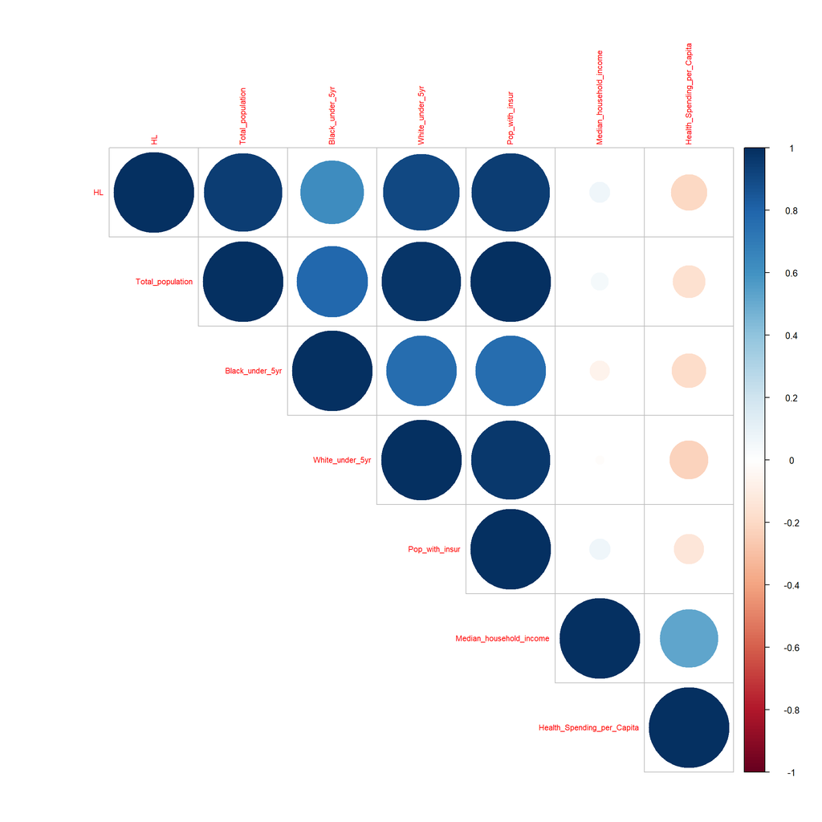

```r
# Visualize correlation matrix
cor_plot_HL <- corrplot::corrplot(cor_matrix, method = "circle", type = "upper", tl.cex = 0.7)
```

```r
# continuing the rest of the code -----------------------
# Plot heatmap
correlation_plot<- ggplot(data = melt(cor_matrix), aes(Var1, Var2, fill = value)) +
  geom_tile(color = "white") +
  scale_fill_gradient2(low = "blue", high = "red", mid = "white",
                       midpoint = 0, limit = c(-1, 1), space = "Lab",
                       name="Correlation") +
  theme_minimal() +
  theme(axis.text.x = element_text(angle = 45, vjust = 1,
                                   size = 10, hjust = 1))
#save the plot
# ggsave(correlation_plot,
#        # file path
#        file="Output/correlation_plot_HL_capstone.png",
#        # figure size
#        width=1200/96,
#        height=900/96,
#        bg = "white")
```

### Check Outcome Variable Distribution

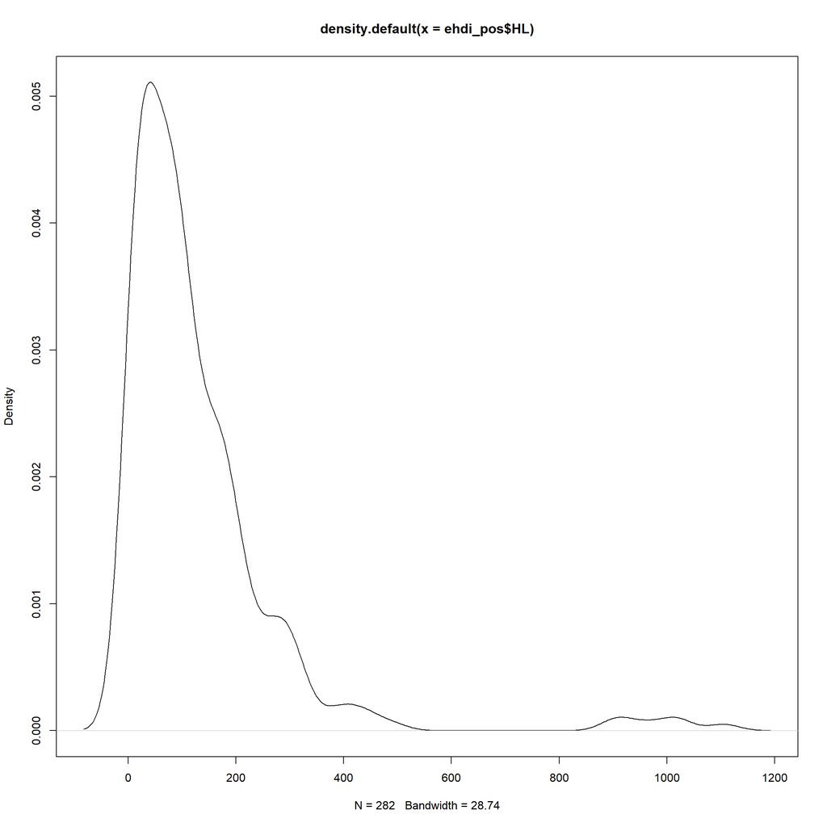

```r
# Check shape of distribution of counts of cases using density plot and histogram
d <- density(ehdi_pos$HL)
plot(d)
```

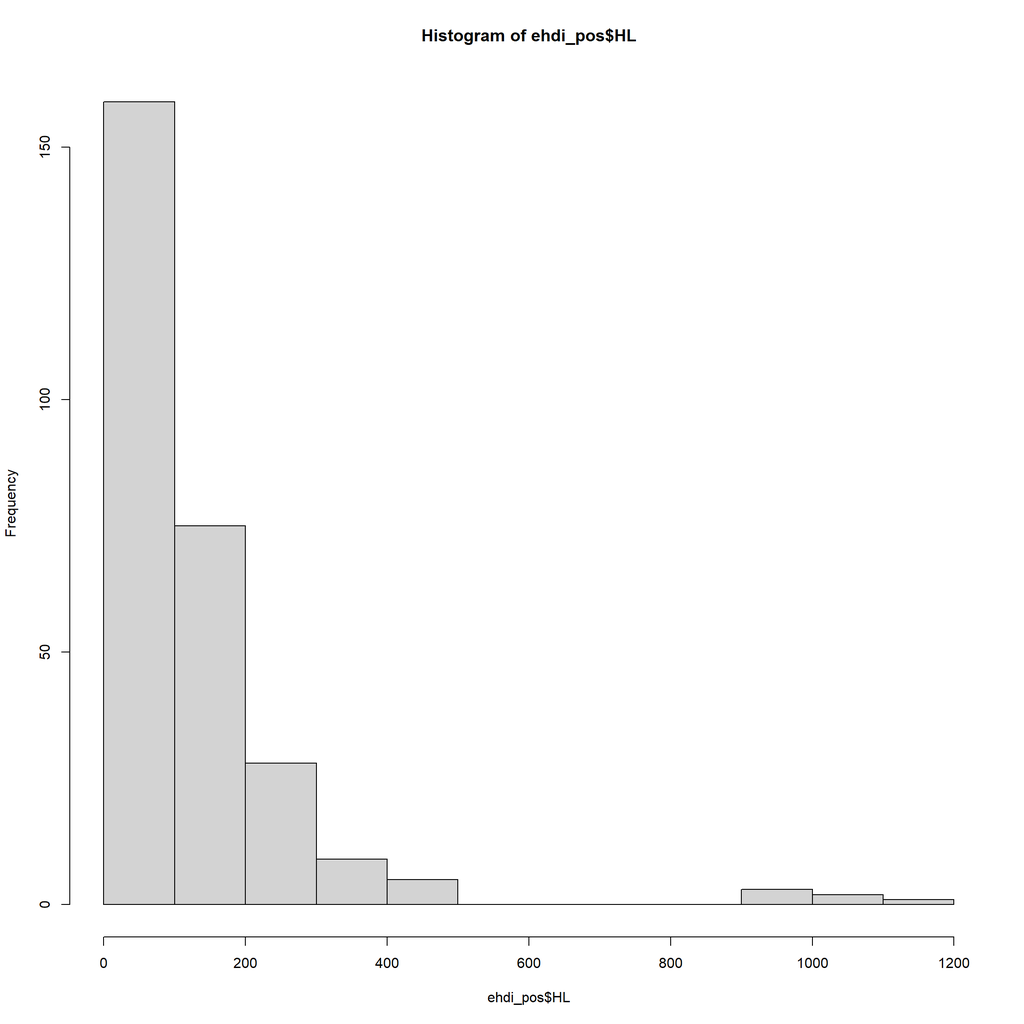

```r
hist(ehdi_pos$HL)
```

```r
#with ggplot
gghisto <- ggplot(ehdi_pos, aes(HL))+
    geom_histogram(color="black", fill="#3182bd")

ggdens <- ggplot(ehdi_pos, aes(HL))+
    geom_density()

# #save the plot
# ggsave(gghisto,
#        # file path
#        file="Output/gghisto_HL_capstone.png",
#        # figure size
#        width=1200/96,
#        height=900/96,
#        bg = "white")
#
# ggsave(ggdens,
#        # file path
#        file="Output/ggdens_HL_capstone.png",
#        # figure size
#        width=1200/96,
#        height=900/96,
#        bg = "white")
```

Our study aims to examine the temporal trends in hearing loss patterns over a six-year period, from 2015 to 2020, taking into account key covariates such as the population of Black infants under 5 years of age, insurance coverage, median household income, and state-level health spending per capita. Additionally, this study seeks to identify any potential shifts in hearing loss patterns attributable to the COVID-19 pandemic.

However, the population sizes (n) differ between the states so we want to account for that by pedicting the log(count/n) from our model. When we exponentiate the beta for state, we will then get the incidence rate ratio. To account for differences in n, we need to use an **offset*, which is defined by log(n) in the model.

### Create an Offset term

```r
# Add an offset term
ehdi_pos_3 <- ehdi_pos %>%
  mutate(offset = log(Total_population))

ehdi_pos_3$State <- factor(ehdi_pos_3$State)  # Convert State to factor
contrasts(ehdi_pos_3$Year) <- contr.treatment(levels(ehdi_pos_3$Year))
```

### Convert Variables State & Year to the appropriate formats

```r
#converting state to factor
ehdi_pos_3$State <- factor(ehdi_pos_3$State)

# convert year to categorical and setting contrasts using treatment coding to compare each year against the baseline category
contrasts(ehdi_pos_3$Year) <- contr.treatment(levels(ehdi_pos_3$Year))
```

The scale() function in R standardizes data by centering and scaling: it first subtracts the mean (centering) and then divides by the standard deviation (scaling) of each variable. Mathematically, for each element x in a variable, the standardized value z is calculated as z = (x−μ)/σ where μ is the mean and σ is the standard deviation of the variable. This process transforms the data to have a mean of 0 and a standard deviation of 1, facilitating comparisons and analyses across different scales.

### Standardization

```r
# Standardize the predictor variables
ehdi_pos_3$Black_under_5yr_std <- scale(ehdi_pos_3$Black_under_5yr, center = TRUE, scale = TRUE)
ehdi_pos_3$Median_household_income_std <- scale(ehdi_pos_3$Median_household_income, center = TRUE, scale = TRUE)
ehdi_pos_3$Pop_with_insur_std <- scale(ehdi_pos_3$Pop_with_insur, center = TRUE, scale = TRUE)
ehdi_pos_3$Health_Spending_per_Capita <- scale(ehdi_pos_3$Health_Spending_per_Capita, center = TRUE, scale = TRUE)
```

### Possion Model

```r
# Fit the Poisson regression model with standardized predictor variables
HL_model <- glmer(HL ~ Year + Black_under_5yr_std + Median_household_income_std +
                                 Pop_with_insur_std + Health_Spending_per_Capita + (1 | State),
                        data = ehdi_pos_3, family = poisson, offset = offset)

# Display the summary of the model
tab_model(HL_model)
```

|  | HL |  |  |
| --- | --- | --- | --- |
| Predictors | Incidence Rate Ratios | CI | p |
| (Intercept) | 0.00 | 0.00 – 0.00 | **<0.001** |
| Year [2016] | 1.00 | 0.96 – 1.04 | 0.890 |
| Year [2017] | 1.03 | 0.98 – 1.08 | 0.217 |
| Year [2018] | 1.04 | 0.97 – 1.11 | 0.254 |
| Year [2019] | 1.01 | 0.93 – 1.10 | 0.853 |
| Year [2020] | 1.08 | 0.98 – 1.20 | 0.137 |
| Black under 5yr std | 0.94 | 0.84 – 1.06 | 0.297 |
| Median household income std | 0.95 | 0.86 – 1.04 | 0.258 |
| Pop with insur std | 0.93 | 0.83 – 1.03 | 0.147 |
| Health Spending per Capita | 0.92 | 0.85 – 0.99 | **0.027** |
| Random Effects |  |  |  |
| σ<sup>2</sup> | 10.81 |  |  |
| τ<sub>00</sub> <sub>State</sub> | 0.10 |  |  |
| ICC | 0.01 |  |  |
| N <sub>State</sub> | 47 |  |  |
| Observations | 282 |  |  |
| Marginal R<sup>2</sup> / Conditional R<sup>2</sup> | 0.002 / 0.011 |  |  |

### IRRs and 95% CIs

```r
df<- tidy(HL_model)
df$IRR<- exp(df$estimate)
df$lowCI <- exp(df$estimate - 1.96*df$std.error)
df$highCI <- exp(df$estimate + 1.96*df$std.error)
knitr::kable(df, caption = "Incidence Rate Ratios and 95% Confidence Intervals for Possion")
```

Incidence Rate Ratios and 95% Confidence Intervals for Possion

| effect | group | term | estimate | std.error | statistic | p.value | IRR | lowCI | highCI |
| --- | --- | --- | --- | --- | --- | --- | --- | --- | --- |
| fixed | NA | (Intercept) | -10.8297172 | 0.0532918 | -203.2155907 | 0.0000000 | 0.0000198 | 0.0000178 | 0.0000220 |
| fixed | NA | Year2016 | -0.0026921 | 0.0194337 | -0.1385294 | 0.8898220 | 0.9973115 | 0.9600382 | 1.0360319 |
| fixed | NA | Year2017 | 0.0299556 | 0.0242692 | 1.2343039 | 0.2170897 | 1.0304087 | 0.9825421 | 1.0806073 |
| fixed | NA | Year2018 | 0.0369193 | 0.0323986 | 1.1395330 | 0.2544809 | 1.0376093 | 0.9737682 | 1.1056358 |
| fixed | NA | Year2019 | 0.0079117 | 0.0427121 | 0.1852326 | 0.8530466 | 1.0079430 | 0.9269979 | 1.0959563 |
| fixed | NA | Year2020 | 0.0790497 | 0.0531303 | 1.4878466 | 0.1367913 | 1.0822581 | 0.9752264 | 1.2010366 |
| fixed | NA | Black_under_5yr_std | -0.0612076 | 0.0587209 | -1.0423480 | 0.2972504 | 0.9406279 | 0.8383660 | 1.0553636 |
| fixed | NA | Median_household_income_std | -0.0532457 | 0.0470930 | -1.1306516 | 0.2582017 | 0.9481470 | 0.8645484 | 1.0398292 |
| fixed | NA | Pop_with_insur_std | -0.0770371 | 0.0531471 | -1.4495074 | 0.1471959 | 0.9258555 | 0.8342641 | 1.0275026 |
| fixed | NA | Health_Spending_per_Capita | -0.0830769 | 0.0376395 | -2.2071724 | 0.0273020 | 0.9202804 | 0.8548320 | 0.9907397 |
| ran_pars | State | sd__(Intercept) | 0.3116969 | NA | NA | NA | 1.3657407 | NA | NA |

### IRR table

```r
# Combine IRR, lowCI, and highCI into a formatted string
df$`IRR (Low CI - High CI)` <- paste0(round(df$IRR, 2), " (", round(df$lowCI, 2), "-", round(df$highCI, 2), ")")
df$`p-value` <- round(df$p.value, 2)
# Select only the formatted IRR and p.value columns
df_final <- df[, c("term", "IRR (Low CI - High CI)", "p-value")]

# Print the final adjusted data frame
knitr::kable(df_final, caption = "IRR table for Possion")
```

IRR table for Possion

| term | IRR (Low CI - High CI) | p-value |
| --- | --- | --- |
| (Intercept) | 0 (0-0) | 0.00 |
| Year2016 | 1 (0.96-1.04) | 0.89 |
| Year2017 | 1.03 (0.98-1.08) | 0.22 |
| Year2018 | 1.04 (0.97-1.11) | 0.25 |
| Year2019 | 1.01 (0.93-1.1) | 0.85 |
| Year2020 | 1.08 (0.98-1.2) | 0.14 |
| Black_under_5yr_std | 0.94 (0.84-1.06) | 0.30 |
| Median_household_income_std | 0.95 (0.86-1.04) | 0.26 |
| Pop_with_insur_std | 0.93 (0.83-1.03) | 0.15 |
| Health_Spending_per_Capita | 0.92 (0.85-0.99) | 0.03 |
| sd__(Intercept) | 1.37 (NA-NA) | NA |

### Vizualize the Possion Results

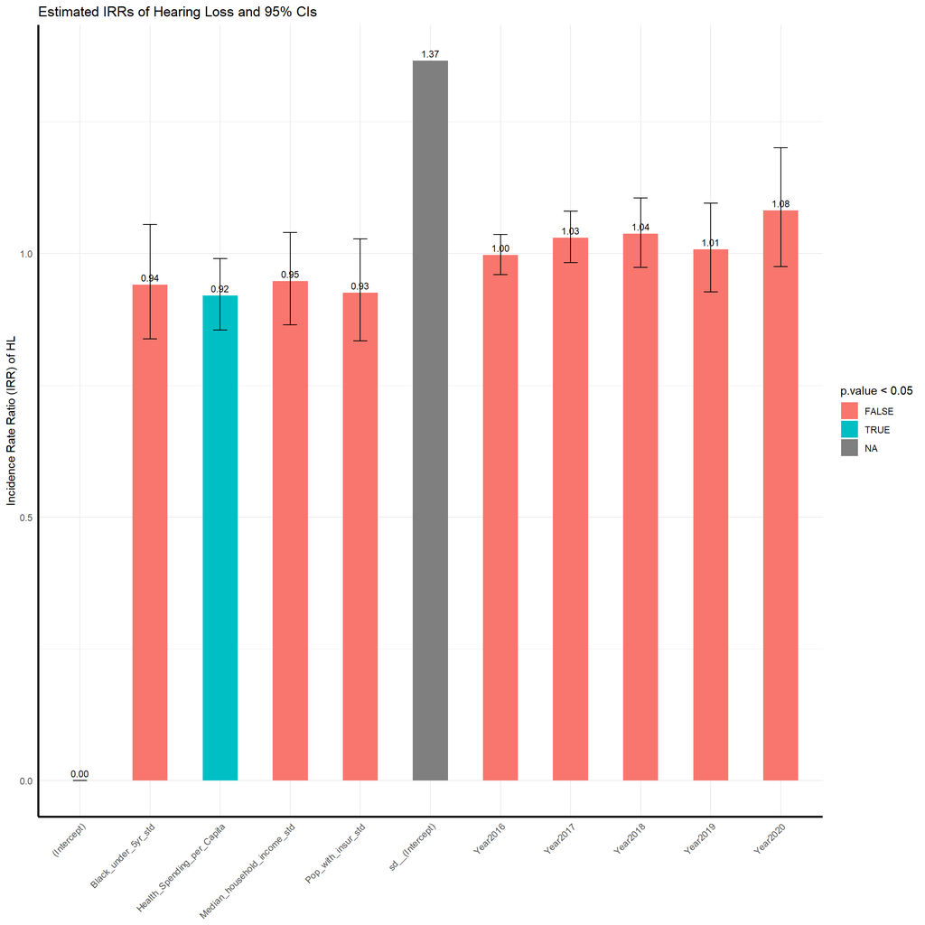

```r
plot_HL<- ggplot(df, aes(x = term, y = IRR, fill = p.value < 0.05, ymin = lowCI, ymax = highCI)) +
  geom_bar(stat = "identity", width = 0.5) +
  geom_errorbar(width = 0.2, position = position_dodge(0.5)) +
  geom_text(aes(label = sprintf("%.2f", IRR)), vjust = -0.5, size = 3, position = position_dodge(0.5)) +
  labs(x = NULL, y = "Incidence Rate Ratio (IRR) of HL", title = "Estimated IRRs of Hearing Loss and 95% CIs") +
  #scale_fill_manual(values = c("FALSE" = "skyblue", "TRUE" = "red"), guide = FALSE) +
  theme_minimal() +
  theme(axis.text.x = element_text(angle = 45, hjust = 1),
        axis.line = element_line(size = 1))

print(plot_HL)
```

```r
# ggsave(plot_HL,
#        # file path
#        file="Output/ggplot_HL_capstone.png",
#        # figure size
#        width=1200/96,
#        height=900/96,
#        bg = "white")
```

### Negative Binomial

```r
# Fit the negative binomial regression model with standardized predictor variables
HL_model_nb <- glmer.nb(HL ~ Year + Black_under_5yr_std + Median_household_income_std +
                          Pop_with_insur_std + Health_Spending_per_Capita +  (1 | State),
                        data = ehdi_pos_3, offset = offset)

# Display the summary of the model
tab_model(HL_model_nb)
```

|  | HL |  |  |
| --- | --- | --- | --- |
| Predictors | Incidence Rate Ratios | CI | p |
| (Intercept) | 0.00 | 0.00 – 0.00 | **<0.001** |
| Year [2016] | 0.98 | 0.93 – 1.05 | 0.624 |
| Year [2017] | 1.00 | 0.93 – 1.07 | 0.990 |
| Year [2018] | 0.98 | 0.91 – 1.06 | 0.621 |
| Year [2019] | 0.94 | 0.86 – 1.04 | 0.236 |
| Year [2020] | 1.01 | 0.90 – 1.13 | 0.872 |
| Black under 5yr std | 0.88 | 0.79 – 0.99 | **0.029** |
| Median household income std | 1.07 | 0.98 – 1.16 | 0.135 |
| Pop with insur std | 1.02 | 0.91 – 1.14 | 0.746 |
| Health Spending per Capita | 0.86 | 0.79 – 0.93 | **<0.001** |
| Random Effects |  |  |  |
| σ<sup>2</sup> | 10.80 |  |  |
| τ<sub>00</sub> <sub>State</sub> | 0.07 |  |  |
| ICC | 0.01 |  |  |
| N <sub>State</sub> | 47 |  |  |
| Observations | 282 |  |  |
| Marginal R<sup>2</sup> / Conditional R<sup>2</sup> | 0.002 / 0.008 |  |  |

### IRR and CI

```r
df1<- tidy(HL_model_nb)
df1$IRR<- exp(df1$estimate)
df1$lowCI <- exp(df1$estimate - 1.96*df1$std.error)
df1$highCI <- exp(df1$estimate + 1.96*df1$std.error)

knitr:: kable(df1, caption = "Incidence Rate Ratios and 95% Confidence Intervals for Negative Binomial")
```

Incidence Rate Ratios and 95% Confidence Intervals for Negative Binomial

| effect | group | term | estimate | std.error | statistic | p.value | IRR | lowCI | highCI |
| --- | --- | --- | --- | --- | --- | --- | --- | --- | --- |
| fixed | NA | (Intercept) | -10.7911694 | 0.0494731 | -218.1219133 | 0.0000000 | 0.0000206 | 0.0000187 | 0.0000227 |
| fixed | NA | Year2016 | -0.0152940 | 0.0311931 | -0.4903011 | 0.6239208 | 0.9848223 | 0.9264154 | 1.0469116 |
| fixed | NA | Year2017 | -0.0004112 | 0.0344812 | -0.0119239 | 0.9904863 | 0.9995889 | 0.9342657 | 1.0694795 |
| fixed | NA | Year2018 | -0.0198870 | 0.0402726 | -0.4938102 | 0.6214402 | 0.9803094 | 0.9059047 | 1.0608253 |
| fixed | NA | Year2019 | -0.0577906 | 0.0487745 | -1.1848536 | 0.2360753 | 0.9438475 | 0.8577963 | 1.0385312 |
| fixed | NA | Year2020 | 0.0094356 | 0.0586197 | 0.1609632 | 0.8721224 | 1.0094803 | 0.8999114 | 1.1323897 |
| fixed | NA | Black_under_5yr_std | -0.1266258 | 0.0579193 | -2.1862445 | 0.0287977 | 0.8810633 | 0.7865117 | 0.9869816 |
| fixed | NA | Median_household_income_std | 0.0657388 | 0.0439792 | 1.4947680 | 0.1349750 | 1.0679477 | 0.9797473 | 1.1640882 |
| fixed | NA | Pop_with_insur_std | 0.0185130 | 0.0572244 | 0.3235160 | 0.7463045 | 1.0186854 | 0.9106043 | 1.1395949 |
| fixed | NA | Health_Spending_per_Capita | -0.1500200 | 0.0421063 | -3.5628906 | 0.0003668 | 0.8606908 | 0.7925115 | 0.9347355 |
| ran_pars | State | sd__(Intercept) | 0.2553348 | NA | NA | NA | 1.2908938 | NA | NA |

```r
# write.csv(df1,
#        # file path
#        file="Output/HL_model_nb_IRR_tbl.csv")
```

calculating the SD for the significant predictors before standardization for interpretation purpose

### SD for Predictors

```r
# Calculate SD for the black population under 5 years
sd_black_population <- sd(ehdi_pos$Black_under_5yr, na.rm = TRUE)

# Calculate SD for health spending per capita
sd_health_spending <- sd(ehdi_pos$Health_Spending_per_Capita, na.rm = TRUE)

# Print the standard deviations
knitr::kable(sd_black_population)
```

| x |
| --- |
| 65731.74 |

```r
knitr::kable(sd_health_spending)
```

| x |
| --- |
| 1606.917 |

### IRR Table

```r
# Combine IRR, lowCI, and highCI into a formatted string
df1$`IRR (Low CI - High CI)` <- paste0(round(df1$IRR, 2), " (", round(df1$lowCI, 2), "-", round(df1$highCI, 2), ")")
df1$`p-value` <- round(df1$p.value, 2)
# Select only the formatted IRR and p.value columns
df1_final <- df1[, c("term", "IRR (Low CI - High CI)", "p-value")]

# Print the final adjusted dataframe
knitr::kable(df1_final, caption = "IRR table for Negative Binomial")
```

IRR table for Negative Binomial

| term | IRR (Low CI - High CI) | p-value |
| --- | --- | --- |
| (Intercept) | 0 (0-0) | 0.00 |
| Year2016 | 0.98 (0.93-1.05) | 0.62 |
| Year2017 | 1 (0.93-1.07) | 0.99 |
| Year2018 | 0.98 (0.91-1.06) | 0.62 |
| Year2019 | 0.94 (0.86-1.04) | 0.24 |
| Year2020 | 1.01 (0.9-1.13) | 0.87 |
| Black_under_5yr_std | 0.88 (0.79-0.99) | 0.03 |
| Median_household_income_std | 1.07 (0.98-1.16) | 0.13 |
| Pop_with_insur_std | 1.02 (0.91-1.14) | 0.75 |
| Health_Spending_per_Capita | 0.86 (0.79-0.93) | 0.00 |
| sd__(Intercept) | 1.29 (NA-NA) | NA |

```r
# write.csv(df1_final,
#        # file path
#        file="Output/neg_binomial_IRR_table.csv")
```

### Likelihood ratio test

```r
#run lrtest to compare models
kable(anova(HL_model, HL_model_nb))# if p-value is <0.05 use negbin
```

|  | npar | AIC | BIC | logLik | deviance | Chisq | Df | Pr(>Chisq) |
| --- | --- | --- | --- | --- | --- | --- | --- | --- |
| HL_model | 11 | 2459.969 | 2500.030 | -1218.984 | 2437.969 | NA | NA | NA |
| HL_model_nb | 12 | 2387.642 | 2431.345 | -1181.821 | 2363.642 | 74.32684 | 1 | 0 |

The LR test indicates that the negative binomial model significantly improve the fit to the data and that we have violated the mean = variance assumption. Therefore the neg binomial model adequately fits these data.

### Vizualize Negative Binomial

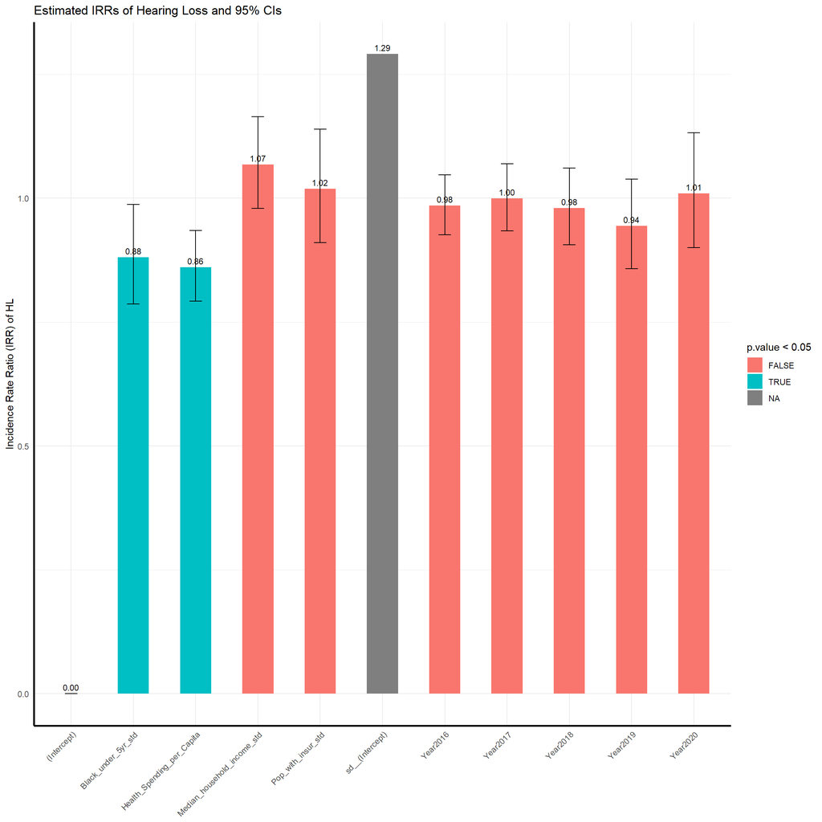

```r
plot_HL_nb<- ggplot(df1, aes(x = term, y = IRR, fill = p.value < 0.05, ymin = lowCI, ymax = highCI)) +
  geom_bar(stat = "identity", width = 0.5) +
  geom_errorbar(width = 0.2, position = position_dodge(0.5)) +
  geom_text(aes(label = sprintf("%.2f", IRR)), vjust = -0.5, size = 3, position = position_dodge(0.5)) +
  labs(x = NULL, y = "Incidence Rate Ratio (IRR) of HL", title = "Estimated IRRs of Hearing Loss and 95% CIs") +
  #scale_fill_manual(values = c("FALSE" = "skyblue", "TRUE" = "red"), guide = FALSE) +
  theme_minimal() +
  theme(axis.text.x = element_text(angle = 45, hjust = 1),
        axis.line = element_line(size = 1))

print(plot_HL_nb)
```

```r
ggsave(plot_HL_nb,
       # file path
       file="Output/ggplot_HL_nb_capstone.png",
       # figure size
       width=1200/96,
       height=900/96,
       bg = "white")
```

Below we further compare the estimates between the two models. The Poisson regression estimates SEs that are usually smaller than those from the negbin.

### Compare Model

```r
model <- stargazer(HL_model, HL_model_nb, title="Model Comparison",
          type="text", align=TRUE, single.row=TRUE, digits=6)

print(model, caption= "Model Comparison")
```

[output not shown]